# Bootstrapping Multiple Linear Regression to Predict Insurance Premiums

Zackary Petrasek

September 20th, 2026

# 1 Introduction

```r
#Reading in dataset
library(readr)

url <- "https://raw.githubusercontent.com/ZackaryPetrasek/STA321/main/homeworks/hw2/insurance.csv"

insurance_data <- read_csv(url)
```

This project is focused on multiple linear regression and bootstrapping multiple linear regression. The data set I choose to use is the “Medical Cost Personal Datasets” from Kaggle (https://www.kaggle.com/datasets/mirichoi0218/insurance). The data comes from a machine learning textbook called “Machine Learning with R” by Brett Lantz. The textbook claims the data came from a random sample of United States citizens who reported on their health insurance premium and these other values which could possible predict the premium. The data set has more than enough observations for multiple linear regression, as the data set has 1338 observations and only 6 explanatory variables. With the minimum observations being 15 times the variable count the observations in this data set are far greater than 90, which would be the minimum needed.

## 1.1 Data set details

The data set has 6 explanatory variables and 1 response variable, insurance premiums, with 1338 observations with the following variables:

-Age(X1): The age of the primary beneficiary. Discrete quantitative explanatory variable.

-Gender(X2): The gender of the primary beneficiary. Two-level categorical explanatory variable with a 1 representing a man and 0 a woman.

-BMI(X3): The BMI of the primary beneficiary. Quantitative explanatory variable.

-Smoke_status(X4): If the primary beneficiary smokes or not. Two-level categorical variable with a 1 representing them smoking and 0 if they do not smoke.

-Children(X5): How many children the primary beneficiary has. Discrete quantitative explanatory variable.

-Region(X6,X7,X8): Region the primary beneficiary is from. Four-level categorical explanatory variable with northeast being the base level and northwest, southeast, and southwest all having their own dummy variable.

-Charges(Y): The premium(or cost) of the insurance. Quantitative response variable.

## 1.2 Question and Application

The question I am looking to answer in this assignment is how to best predict the insurance premiums based on age, gender, BMI, smoking status, number of children, and region of the US they live in. This can be important to understand how insurance companies price your policy, and how you could possibly lower your insurance cost.

# 2 Exploratory analysis

In this section I will create dummy variables for existing categorical variables. Then perform linear regression on the region dummy variables to see if there is a significant association between region and price to include in the final model.

Region Regression Coefficients

|  | Estimate | Std. Error | t value | Pr(>\|t\|) |
| --- | --- | --- | --- | --- |
| (Intercept) | 13406.3845 | 671.2966 | 19.970880 | 0.0000000 |
| sw | -1059.4471 | 948.6263 | -1.116823 | 0.2642713 |
| se | 1329.0269 | 922.9071 | 1.440044 | 0.1500896 |
| nw | -988.8091 | 948.6263 | -1.042359 | 0.2974341 |

```
Analysis of Variance Table

Model 1: charges ~ gender + age + smoke_status + sw + se + nw + age +
    children + bmi
Model 2: charges ~ age + smoke_status + gender + children + bmi
  Res.Df        RSS Df  Sum of Sq      F  Pr(>F)
1   1329 4.8840e+10
2   1332 4.9073e+10 -3 -233431209 2.1173 0.09622 .
---
Signif. codes:  0 '***' 0.001 '**' 0.01 '*' 0.05 '.' 0.1 ' ' 1
```

Full Model Regression Coefficients

|  | Estimate | Std. Error | t value | Pr(>\|t\|) |
| --- | --- | --- | --- | --- |
| (Intercept) | -12052.4620 | 951.26043 | -12.6699919 | 0.0000000 |
| age | 257.7350 | 11.90389 | 21.6513323 | 0.0000000 |
| bmi | 322.3642 | 27.41860 | 11.7571362 | 0.0000000 |
| children | 474.4111 | 137.85580 | 3.4413577 | 0.0005967 |
| gender | -128.6399 | 333.36051 | -0.3858881 | 0.6996412 |
| smoke_status | 23823.3925 | 412.52338 | 57.7504052 | 0.0000000 |

```
Analysis of Variance Table

Model 1: charges ~ gender + age + smoke_status + age + children + bmi
Model 2: charges ~ age + smoke_status + children + bmi
  Res.Df        RSS Df Sum of Sq      F Pr(>F)
1   1332 4.9073e+10
2   1333 4.9078e+10 -1  -5486063 0.1489 0.6996
```

Since the region variable is not a significant predictor of insurance premiums, and is not known to be highly correlated with health insurance costs, I will not be using it in my regression model. Gender is also shown not to be a significant predictor of charges so I will drop that as well. That leave me with age, number of children, BMI, and smoking status as the four variables I will be using to predict the cost of insurance premiums.

## 2.1 Full model and diagnostics

We start with a linear model that includes all remaining predictor variables.

```r
full.model = lm(charges ~ ., modeldata)
kable(summary(full.model)$coef, caption ="Full Model Regression Coefficients")
```

Full Model Regression Coefficients

|  | Estimate | Std. Error | t value | Pr(>\|t\|) |
| --- | --- | --- | --- | --- |
| (Intercept) | -12102.7694 | 941.98394 | -12.848169 | 0.0000000 |
| age | 257.8495 | 11.89639 | 21.674608 | 0.0000000 |
| bmi | 321.8514 | 27.37763 | 11.755999 | 0.0000000 |
| children | 473.5023 | 137.79167 | 3.436364 | 0.0006077 |
| smoke_status | 23811.3998 | 411.21971 | 57.904325 | 0.0000000 |

With this model we can then check the residuals to check for the validity of using the model for predictions.

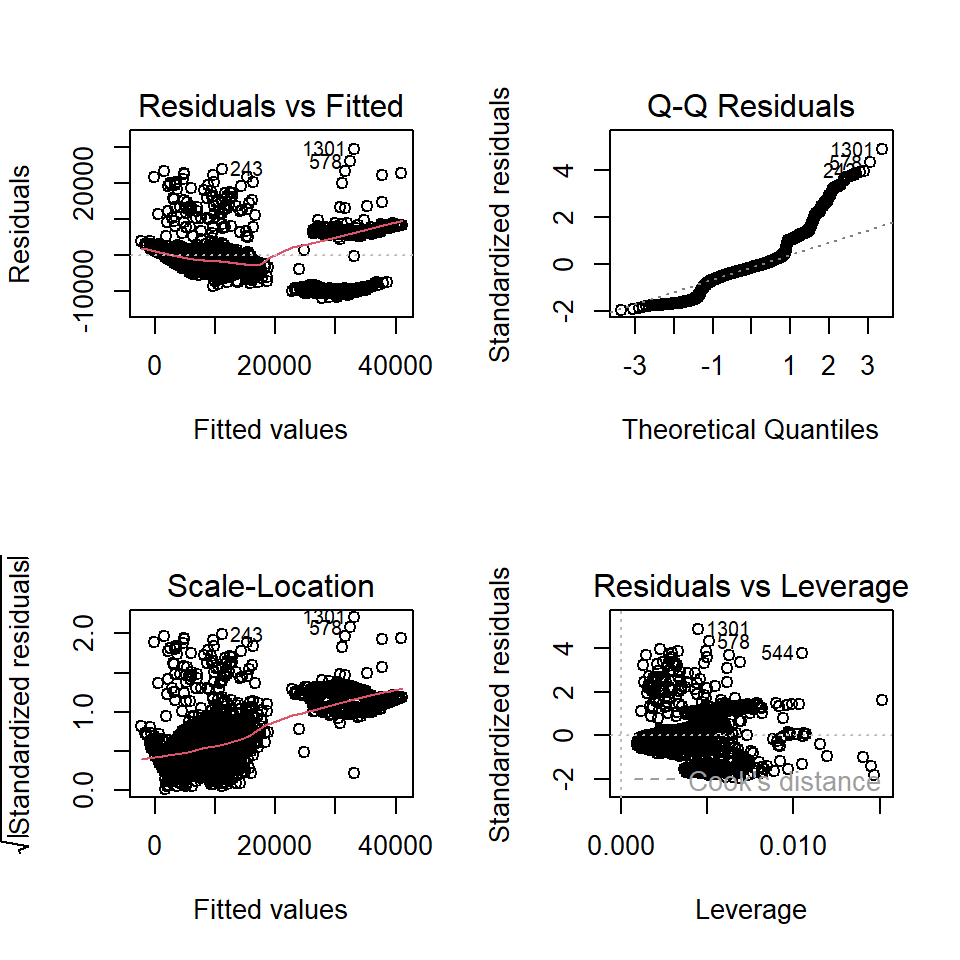

Residual plots of the full model

```r
#Use residual plots to check for the validity of the residual assumptions
par(mfrow=c(2,2))
plot(full.model)
```

The plots show large violations of residual assumptions :

- The variance of the residuals is not constant.
- The QQ plot indicates the distribution of residuals is significantly off the normal distribution.
- The residual plot seems to show a distinct clustering pattern, with the higher fitted value groups being the groups who smoke.

Due to all of these errors we should not consider using this model to predict actual values. To try to fix these residual issues we need to try transformation methods to see if any make the residuals normal with constant variance. If this is not possible then we would have to use non-parametric methods.

We first perform Box-Cox transformation to correct the non-constant variance and correct the non-normality of the QQ plot. We can also check for multicollinearity using the VIF function.

```r
#Find vif values to check for multicollinearity
vif(full.model)
```

```
         age          bmi     children smoke_status
    1.014498     1.012194     1.001950     1.000745
```

The VIF indices show that there is no significant issues on multicollinearity. With all of the VIF values being close to 1 makes it reasonable to assume that the variables have little to no overlap with each other.

## 2.2 Candidate model building

We first perform Box-Cox transformation and then choose appropriate transformations for both response and predictor variables to build candidate regression models.

### 2.2.1 Box-Cox Transformations

With many issues with the residuals in the model, the first step to try to fix this is by performing box-cox transformations to normalize the data and fix the residual issues.

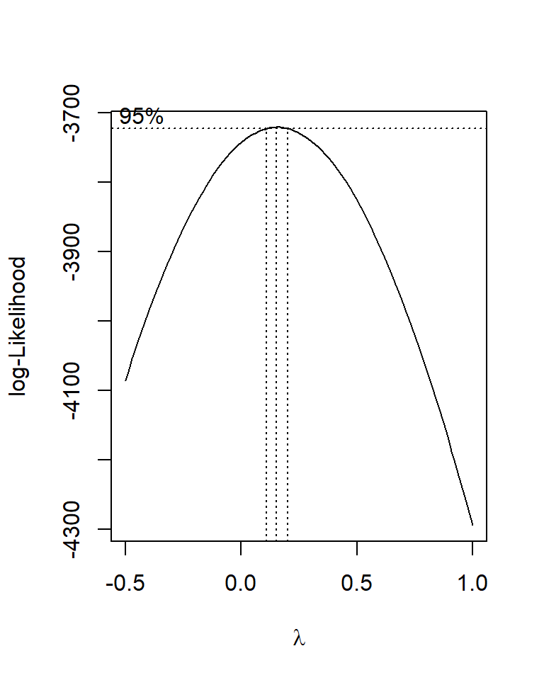

Box-cox optimal lambda graph

```r
#Box-Cox transformation on the data.
bc <- boxcox(full.model, lambda= seq(-0.5,1, by=.1))
```

Using the plot generated by the box cox transformation we can see that the optimal lambda is somewhere between 0 and 0.5 with larger than 95% confidence. Thus, the next step is to generate possible models that could fix the residual issues and compare them to see which is the best predictor for insurance premiums.

### 2.2.2 Square-root Transformation

The first model we are going to create is a model using a square-root transformation on the response variable, premium cost.

```r
#Create and report the coefficients for the square-root model
sqrt.model = lm((charges)^0.5 ~ ., modeldata)
kable(summary(sqrt.model)$coef, caption = "Square-root model")
```

Square-root model

|  | Estimate | Std. Error | t value | Pr(>\|t\|) |
| --- | --- | --- | --- | --- |
| (Intercept) | -0.8727681 | 3.5084081 | -0.2487647 | 0.8035811 |
| age | 1.4049524 | 0.0443080 | 31.7088109 | 0.0000000 |
| bmi | 0.9299696 | 0.1019677 | 9.1202395 | 0.0000000 |
| children | 3.2533112 | 0.5132035 | 6.3392231 | 0.0000000 |
| smoke_status | 90.5554163 | 1.5315830 | 59.1253733 | 0.0000000 |

Residual plots are given below.

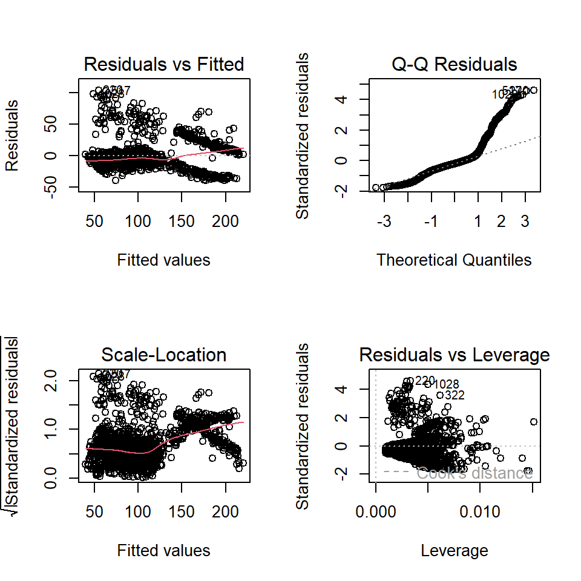

Square-root residual plots

```r
#Get residual plots to check for issues in the square-root model
par(mfrow = c(2,2))
plot(sqrt.model)
```

There seems to still be lots of issues in the residual even with the square-root transformation. The Q-Q plot shows the data is not very normal, and the residual plots show that the residuals are still grouped without very constant variance.

### 2.2.3 Log-Transformation

We take the log transformation of the sale price according to the Box-Cox transformation and then build a linear regression based on the log price.

```r
#Create and report the coefficients for the log model
log.model = lm(log(charges) ~ age+children+smoke_status+bmi, modeldata)
kable(summary(log.model)$coef, caption = "log-transformed model")
```

log-transformed model

|  | Estimate | Std. Error | t value | Pr(>\|t\|) |
| --- | --- | --- | --- | --- |
| (Intercept) | 6.9827766 | 0.0697227 | 100.150756 | 0e+00 |
| age | 0.0347826 | 0.0008805 | 39.501726 | 0e+00 |
| children | 0.1011976 | 0.0101989 | 9.922403 | 0e+00 |
| smoke_status | 1.5432438 | 0.0304372 | 50.702597 | 0e+00 |
| bmi | 0.0106096 | 0.0020264 | 5.235700 | 2e-07 |

Residual plots are given below.

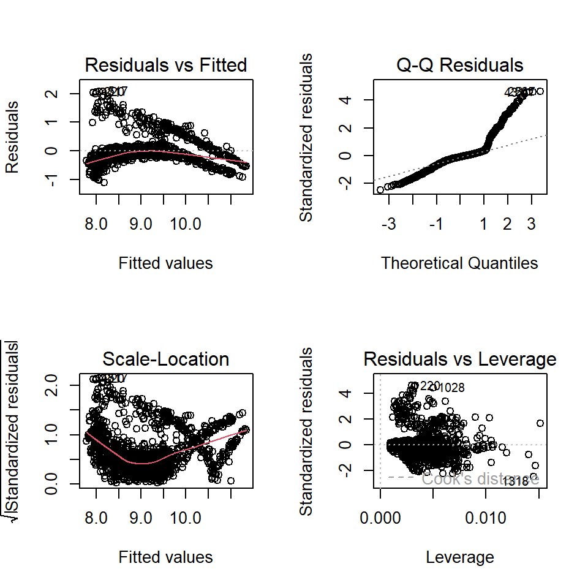

Log residual plots

```r
#Get residual plots to check for issues in the log model
par(mfrow = c(2,2))
plot(log.model)
```

The issues in the residuals still are not fixed even with the log transformation of the response variable. It does slightly fix the grouping issue in the residual plot, going from three groups to two, but normality and constant variance are still not there in this model.

### 2.2.4 Box-Cox transformation

With the first two methods not correcting the issues in the residual assumptions, the next step we could try to look at would be if the exact box-cox transformation would fix the issues. To do this we take the optimal lambda from the earlier graph to transform the response variable according to the formula,

newy=(y^(optimal_lambda)-1)/optimal_lambda

,where in our case the optimal lambda is 0.15 repeating(about 0.152).

```r
#Transform charges using optimal lambda found in box-cox plot earlier
optimal_lambda <- bc$x[which.max(bc$y)]
optimal_lambda
```

```
[1] 0.1515152
```

```r
modeldata$bcy <- (((modeldata$charges)^(optimal_lambda)-1)/optimal_lambda)
#Create and report the coefficients for the box-cox model
bc.model = lm(bcy~ age+children+smoke_status+bmi, modeldata)
kable(summary(bc.model)$coef, caption = "box-cox model")
```

box-cox model

|  | Estimate | Std. Error | t value | Pr(>\|t\|) |
| --- | --- | --- | --- | --- |
| (Intercept) | 11.4794998 | 0.2722184 | 42.170189 | 0 |
| age | 0.1300150 | 0.0034379 | 37.818507 | 0 |
| children | 0.3536779 | 0.0398196 | 8.882006 | 0 |
| smoke_status | 6.4518571 | 0.1188360 | 54.292131 | 0 |
| bmi | 0.0510620 | 0.0079117 | 6.453980 | 0 |

Residual plots are given below.

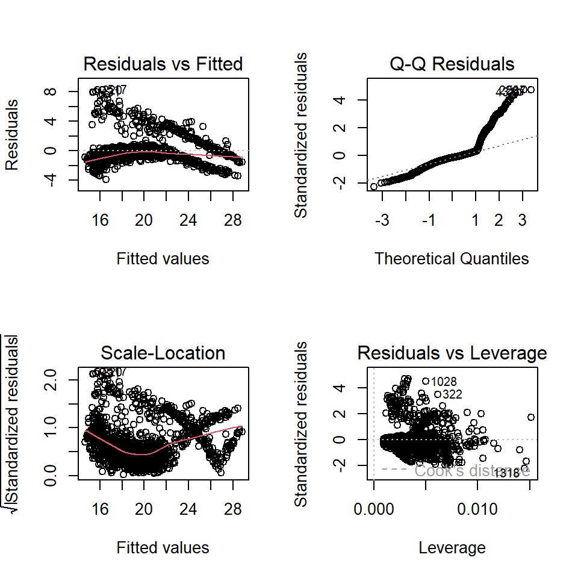

Box-Cox residual plots

```r
#Get residual plots to check for issues in the box-cox model
par(mfrow = c(2,2))
plot(bc.model)
```

Even after using an exact box-cox transformation there are still issues in the residuals, while the data looks much better on the residual plot there are still patterns in the residuals and noticeable issues with normality in the Q-Q plot.

## 2.3 Goodness of Fit

To select which is the best model it is important to look at different measures to see how well they predict the true insurance premium cost. However, it is important to note that AIC, SSE, SBC, and PRESS all depend on the magnitude of the response. Since we transformed the response variable we will not be able to use these values to determine the fit of the model. Instead we should focus on R square, adjusted R squared, and Cp.

```r
select=function(m){ # m is an object: model
 e = m$resid                           # residuals
 n0 = length(e)                        # sample size
 SSE=(m$df)*(summary(m)$sigma)^2       # sum of squared error
 R.sq=summary(m)$r.squared             # Coefficient of determination: R square!
 R.adj=summary(m)$adj.r                # Adjusted R square
 MSE=(summary(m)$sigma)^2              # square error
 Cp=(SSE/MSE)-(n0-2*(n0-m$df))         # Mellow's p
 AIC=n0*log(SSE)-n0*log(n0)+2*(n0-m$df)          # Akaike information criterion
 SBC=n0*log(SSE)-n0*log(n0)+(log(n0))*(n0-m$df)  # Schwarz Bayesian Information criterion
 X=model.matrix(m)                     # design matrix of the model
 H=X%*%solve(t(X)%*%X)%*%t(X)          # hat matrix
 d=e/(1-diag(H))
 PRESS=t(d)%*%d   # predicted residual error sum of squares (PRESS)- a cross-validation measure
 tbl = as.data.frame(cbind(SSE=SSE, R.sq=R.sq, R.adj = R.adj, Cp = Cp, AIC = AIC, SBC = SBC, PRD = PRESS))
 names(tbl)=c("SSE", "R.sq", "R.adj", "Cp", "AIC", "SBC", "PRESS")
 tbl
}
##Create table using the above formula for the 5 models created to select the best one
output.sum = rbind(select(full.model), select(sqrt.model), select(log.model), select(bc.model))
row.names(output.sum) = c("full.model", "sqrt.model", "log.model", "bc.model" )
kable(output.sum, caption = "Goodness-of-fit Measures of Candidate Models")
```

Goodness-of-fit Measures of Candidate Models

|  | SSE | R.sq | R.adj | Cp | AIC | SBC | PRESS |
| --- | --- | --- | --- | --- | --- | --- | --- |
| full.model | 4.907845e+10 | 0.7496945 | 0.7489434 | 5 | 23314.956 | 23340.950 | 4.952310e+10 |
| sqrt.model | 6.808071e+05 | 0.7768644 | 0.7761948 | 5 | 8348.554 | 8374.548 | 6.863151e+05 |
| log.model | 2.688758e+02 | 0.7621566 | 0.7614429 | 5 | -2137.064 | -2111.070 | 2.710221e+02 |
| bc.model | 4.098630e+03 | 0.7719745 | 0.7712903 | 5 | 1507.860 | 1533.855 | 4.131048e+03 |

Before picking which model we will more forward with it is important to note that with the residual issues, none of these model should be used for actual prediction. At this point we are selecting a model to move forward with to bootstrap in the next section. As noted before the main indicators to focus on are R squared and R squared adjusted as they are based on a portion of explained variance rather than magnitude. Due to the small difference in these values across all models, and the issues not being fixed by any of the transformation, we will more forward with the non-transformed model. While it has slightly lower R squared and adjusted R squared values, the difference is very slight. Since it is much easier to work with and interpret it is worth losing the small amount of explained variance from the other models.

# 3 Regression model

```r
#Final model reporting
kable(summary(full.model)$coef, caption = "Inferential Statistics of Final Model")
```

Inferential Statistics of Final Model

|  | Estimate | Std. Error | t value | Pr(>\|t\|) |
| --- | --- | --- | --- | --- |
| (Intercept) | -12102.7694 | 941.98394 | -12.848169 | 0.0000000 |
| age | 257.8495 | 11.89639 | 21.674608 | 0.0000000 |
| bmi | 321.8514 | 27.37763 | 11.755999 | 0.0000000 |
| children | 473.5023 | 137.79167 | 3.436364 | 0.0006077 |
| smoke_status | 23811.3998 | 411.21971 | 57.904325 | 0.0000000 |

Since the sample size is large, the central limit theorem can validate the p-values, which are all showing up as 0, meaning the coefficients for the explanatory variables are all significantly different from 0. This means they all have significant effect on the insurance premiums and no variables need to be removed from the model. However, it is still important to know this does not validate the model for prediction as the overall model has issues with residual assumptions. Due to the residual assumptions not being met the next step we will take is to look at non-parametric bootstrapping methods.

# 4 Bootstrapping

As the residual issues were unable to be fixed with transformation the next step is to use non-parametric methods to fix this. In this case we will use bootstrapping to create confidence intervals for the coefficients. We will do this in two different ways. In the first way we will do case bootstrapping, that is taking a sample from the dataset, with replacement, and fitting the final model selected in the previous step, in this case the non-transformed model, and gathering a 95% confidence interval for all of the coefficients.

The other way we could do this is to instead is to bootstrap the residuals themselves, called residual bootstrapping. The way you do this is sample as many residuals as there are observations, with replacement, and assign each observation with one of those randomly sampled residuals. We then compute the coefficients for the variables in the previously selected model. Across large samples with replacement the residuals get normalized directly.

Both of these methods are valid and for the sake of learning I will be performing both of these methods and reviewing which one is better for my data

## 4.1 Case Bootstrapping

As mentioned before in case bootstrapping we simply take a sample of observations with replacement from the original dataset and then look at the confidence intervals for the coefficients across thousands of samples.

```r
#setting up a matrix to take in the bootstrapped coefficients
B = 5000

num.p = dim(model.frame(full.model))[2]
smpl.n = dim(model.frame(full.model))[1]
coef.mtrx = matrix(rep(0, B*num.p), ncol = num.p)
#running the case bootstrap method by re-sampling from original dataset
for (i in 1:B){
  bootc.id = sample(1:smpl.n, smpl.n, replace = TRUE)
  charges.btc = lm(charges ~ age+children+bmi+smoke_status, data=modeldata[bootc.id, ])
  coef.mtrx[i,] = coef(charges.btc)
}
```

```r
boot.hist = function(bt.coef.mtrx, var.id, var.nm) {

  # extract the bootstrap coefficients
  coef_data <- bt.coef.mtrx[, var.id]

  # generate normal curve data
  x1.1 <- seq(min(coef_data), max(coef_data), length = 300)
  y1.1 <- dnorm(x1.1, mean = mean(coef_data), sd = sd(coef_data))

  # set up y limits for the plot
  highestbar = max(hist(coef_data, plot = FALSE)$density)
  ylimit <- max(c(y1.1, highestbar), na.rm=TRUE)

  # create the histogram
  hist(coef_data, probability = TRUE, main = var.nm, xlab = "",
       col = "azure1", ylim = c(0, ylimit), border = "lightseagreen")

  # add the normal and actual distribution lines
  lines(x = x1.1, y = y1.1, col = "red3", lwd = 2)
  lines(density(coef_data, adjust = 2), col = "blue", lwd = 2)
}
```

To visualize the coefficients we can create a function that will plot histograms with a red line to represent the normal curve and a blue line to represent the density of the coefficient values from the bootstrapping samples.

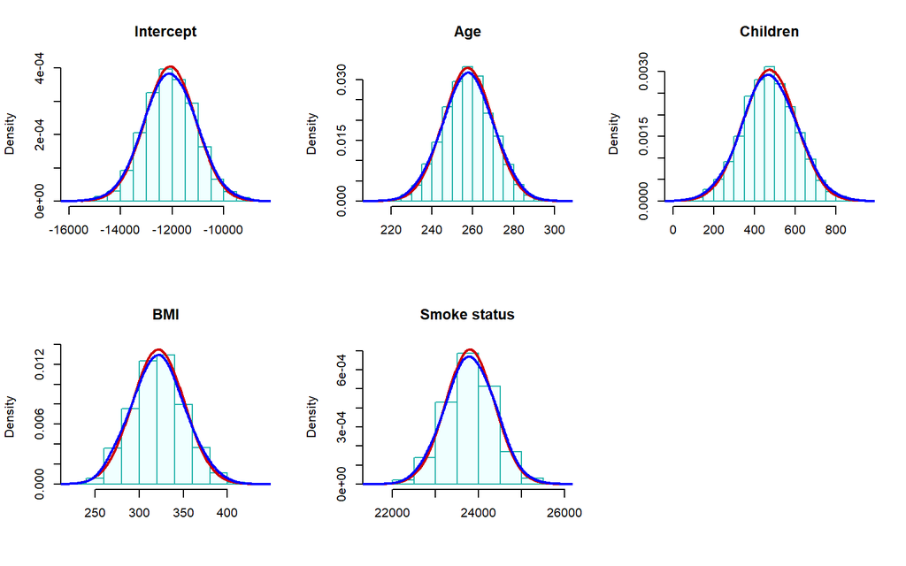

Case bootstrap density plots

```r
# use the above function to plot the distributions for the coefficients
par(mfrow = c(2, 3))  # 2 rows, 3 columns
boot.hist(bt.coef.mtrx = coef.mtrx, var.id = 1, var.nm = "Intercept")
boot.hist(bt.coef.mtrx = coef.mtrx, var.id = 2, var.nm = "Age")
boot.hist(bt.coef.mtrx = coef.mtrx, var.id = 3, var.nm = "Children")
boot.hist(bt.coef.mtrx = coef.mtrx, var.id = 4, var.nm = "BMI")
boot.hist(bt.coef.mtrx = coef.mtrx, var.id = 5, var.nm = "Smoke status")
```

Looking at the plots we can see that coefficients are very close to the normal distributions. The next step is interpreting these values is to compare 95% confidence intervals of these coefficients with the original model.

```r
# make strings of the confidence intervals
num.p = dim(coef.mtrx)[2]
btc.ci = NULL
btc.wd = NULL
for (i in 1:num.p){
  lci.025 = round(quantile(coef.mtrx[, i], 0.025, type = 2),8)
  uci.975 = round(quantile(coef.mtrx[, i],0.975, type = 2 ),8)
  btc.wd[i] =  uci.975 - lci.025
  btc.ci[i] = paste("[", round(lci.025,4),", ", round(uci.975,4),"]")
 }
#create table to look at oringnal model summary and bootstrap CI's
kable(as.data.frame(cbind(formatC(summary(full.model)$coef,4,format="f"), btc.ci.95=btc.ci)),
      caption = "Regression Coefficient Matrix")
```

Regression Coefficient Matrix

[output not shown]

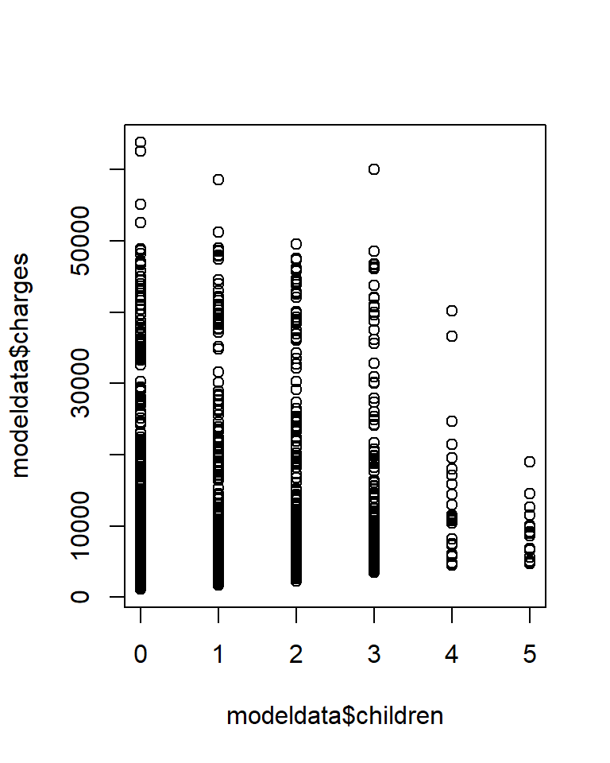

Charges vs. children

```r
#create scatterplot to help with my interpretation
plot(modeldata$charges ~ modeldata$children)
```

## 4.2 Residual bootstrapping

The second way you can do bootstrapping is by looking at the residuals. Instead of sampling observations, we could instead sample residuals from the original model. This is a different form of bootstrapping called residual bootstrapping. As mentioned earlier we will do both methods and compare their results afterwards. One thing to note before we get into running the residual bootstrapping method. Residual bootstrapping still does assume some sort of homoscedasticity, so with our data it should not be selected to report. However, I will still go through the process to demonstrate how it works.

```r
#set up the matrix for storing coefficints
B=5000
num.p = dim(model.matrix(full.model))[2]
samp.n = dim(model.matrix(full.model))[1]
btr.mtrx = matrix(rep(0,num.p*B), ncol=num.p)
#run bootstrap method with sampled residuals instead of observations
for (i in 1:B){
  bt.charges = full.model$fitted.values + sample(full.model$residuals, samp.n, replace = TRUE)
  modeldata$bt.charges=  bt.charges
  btr.model = lm(bt.charges ~ age+children+bmi+smoke_status, data = modeldata)
  btr.mtrx[i,]=btr.model$coefficients
}
```

We can use the sample plotting function created above to look at the normality of the coefficients.

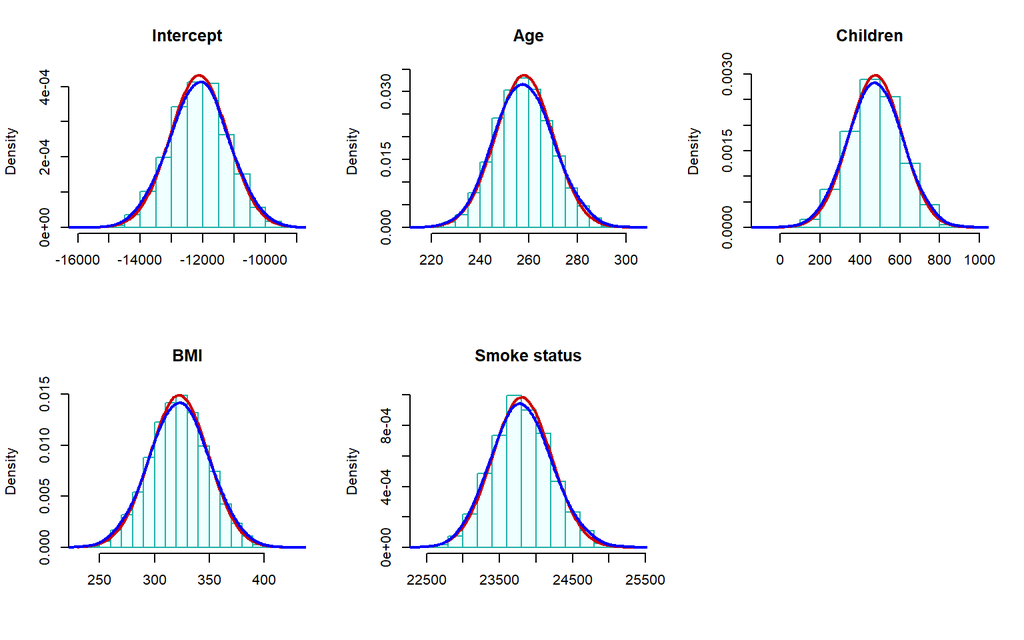

Residual bootstrap density plots

```r
# use the earlier function to plot the distributions for the coefficients
par(mfrow = c(2, 3))  # 2 rows, 3 columns
boot.hist(bt.coef.mtrx = btr.mtrx, var.id = 1, var.nm = "Intercept")
boot.hist(bt.coef.mtrx = btr.mtrx, var.id = 2, var.nm = "Age")
boot.hist(bt.coef.mtrx = btr.mtrx, var.id = 3, var.nm = "Children")
boot.hist(bt.coef.mtrx = btr.mtrx, var.id = 4, var.nm = "BMI")
boot.hist(bt.coef.mtrx = btr.mtrx, var.id = 5, var.nm = "Smoke status")
```

Same as last time, all of the coefficients seem to be very close to the normal distribution.

```r
#create string versions of the confidence intervals
num.p = dim(btr.mtrx)[2]
btr.ci = NULL
btr.wd = NULL
for (i in 1:num.p){
  lci.025 = round(quantile(btr.mtrx[, i], 0.025, type = 2),8)
  uci.975 = round(quantile(btr.mtrx[, i],0.975, type = 2 ),8)
  btr.wd[i] =  uci.975 - lci.025
  btr.ci[i] = paste("[", round(lci.025,4),", ", round(uci.975,4),"]")
 }
#create table with original model and residual bootstrap CI
kable(as.data.frame(cbind(formatC(summary(full.model)$coef,4,format="f"), btr.ci.95=btr.ci)),
      caption = "Regression Coefficient Matrix")
```

Regression Coefficient Matrix

|  | Estimate | Std. Error | t value | Pr(>\|t\|) | btr.ci.95 |
| --- | --- | --- | --- | --- | --- |
| (Intercept) | -12102.7694 | 941.9839 | -12.8482 | 0.0000 | [ -13956.6589 , -10321.5544 ] |
| age | 257.8495 | 11.8964 | 21.6746 | 0.0000 | [ 235.6129 , 281.9428 ] |
| bmi | 321.8514 | 27.3776 | 11.7560 | 0.0000 | [ 215.6107 , 742.6096 ] |
| children | 473.5023 | 137.7917 | 3.4364 | 0.0006 | [ 269.506 , 374.5273 ] |
| smoke_status | 23811.3998 | 411.2197 | 57.9043 | 0.0000 | [ 23035.4769 , 24636.4086 ] |

## 4.3 Comparing Methods

Now that we have the full model and have used our two different bootstrapping methods, we can look at a table to compare all of this information.

```r
##create a plot to compare the original model with both bootstrap CI's
kable(as.data.frame(cbind(formatC(summary(full.model)$coef,4,format="f"), btc.ci.95=btc.ci,btr.ci.95=btr.ci)),
      caption="Final Combined Inferential Statistics: p-values and Bootstrap CIs")
```

Final Combined Inferential Statistics: p-values and Bootstrap CIs

|  | Estimate | Std. Error | t value | Pr(>\|t\|) | btc.ci.95 | btr.ci.95 |
| --- | --- | --- | --- | --- | --- | --- |
| (Intercept) | -12102.7694 | 941.9839 | -12.8482 | 0.0000 | [ -13991.0777 , -10124.845 ] | [ -13956.6589 , -10321.5544 ] |
| age | 257.8495 | 11.8964 | 21.6746 | 0.0000 | [ 233.6386 , 281.1471 ] | [ 235.6129 , 281.9428 ] |
| bmi | 321.8514 | 27.3776 | 11.7560 | 0.0000 | [ 218.9805 , 733.8851 ] | [ 215.6107 , 742.6096 ] |
| children | 473.5023 | 137.7917 | 3.4364 | 0.0006 | [ 264.9534 , 380.8903 ] | [ 269.506 , 374.5273 ] |
| smoke_status | 23811.3998 | 411.2197 | 57.9043 | 0.0000 | [ 22691.7111 , 24881.2114 ] | [ 23035.4769 , 24636.4086 ] |

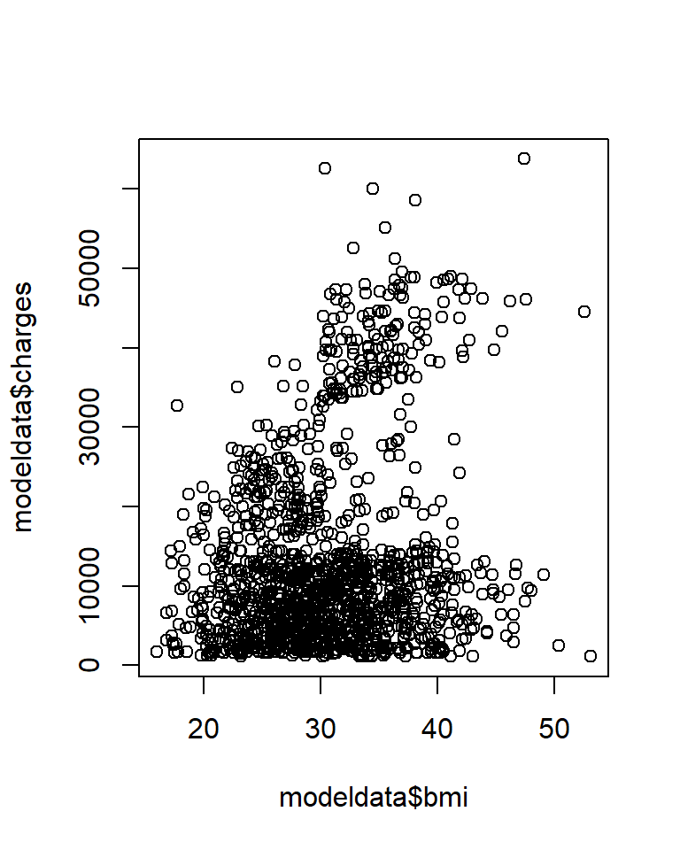

Charges vs. BMI

```r
#create scatterplot to help interpret results
plot(modeldata$charges ~ modeldata$bmi)
```

### 4.3.1 Comparing bootstrap methods

Now it is time to compare the two different bootstrapping methods, case bootstrapping vs residual bootstrapping.The best way to compare the two methods is to compare the width of the confidence intervals. The smaller the interval the more precise the estimation is and gives a clearer picture of what the coefficient should be.

```r
#create plot with bootstrap widths
kable(round(cbind(btc.wd, btr.wd),4), caption="width of the two bootstrap confidence intervals")
```

width of the two bootstrap confidence intervals

| btc.wd | btr.wd |
| --- | --- |
| 3866.2327 | 3635.1045 |
| 47.5086 | 46.3298 |
| 514.9046 | 526.9989 |
| 115.9368 | 105.0213 |
| 2189.5003 | 1600.9317 |

Looking at the table it seems like the residual bootstrap confidence intervals are more narrow, which is what we want to pick.

However, as noted earlier the residual bootstrapping method assumes homoscedasticity in the residuals. Since we do not have that with our model the cases bootstrapping confidence intervals are the ones we want to look at when reporting our findings. So despite having a narrower confidence interval the findings are not as valid as the cases method.

# 5 Summary

The analysis of the data shows how age, BMI, amount of children, and smoking status affect insurance premiums(Charges).

The final model we are using is Charges = -1.2102769^{4} + 257.8495073(age) + 321.8514025(BMI) + 473.5023156(children) + 2.38114^{4}(smoke_status).

As discussed in the last section it makes more sense to look at the cases bootstrap confidence intervals instead of the final model. Because the model we picked was not transformed, the meaning of the coefficients is that for every one increase in the variable, the value of charges is expected to go up by between:

-Age: [ 233.6386 , 281.1471 ]

-Smoke_status(if the person smokes their charges value goes up by): [ 22691.7111 , 24881.2114 ]

The largest takeaway from these values is that smoking substantially increases insurance premiums. Increases of age, BMI, and number of children all add a smaller, but still relevant amount to insurance as well.

# 6 Discussion

Throughout the assignment we looked at building a multiple linear regression model, using transformation techniques to try and fix residual issues, as well as used two different bootstrapping methods when the transformation techniques did not work. In the end we chose to report the cases bootstrap regression confidence intervals to interpret the results.

The biggest drawback of the assignment was the large issues in the residual assumptions which was not able to be fixed by transformation. Due to this we had to rely on non-parametric methods to best represent the model. This is not ideal as non-parametric methods have less statistical power compared to parametric methods. A possible way to improve this project would be to get more predictor variables to see if there are any other variables that could help reduce the grouping effect caused by the smoking variable. The large impact that smoking has on the result is a big reason why there were issues with normality and homoscedasticity.

Returning back to the application part of this assignment we can clearly see that not smoking is the best thing you can do to lower your insurance premium. Additionally, it seems like having fewer kids and having a lower BMI can help lower the premium as well.